# 3C 279: Modelling Brightness and Variability Before vs. After the 2023 Dimming

A mixed-effects (GLMM/LMM) analysis of AAVSO magnitudes

Author

AAVSO — analysis for Rodney H

Published

July 1, 2026

```r
# Utility functions ----------------------------------------------------------

#' Julian Date -> calendar Date (UTC).
#' JD 2440587.5 corresponds to 1970-01-01 00:00 UTC (the Unix epoch).
jd_to_date <- function(jd) as.Date(jd - 2440587.5, origin = "1970-01-01")

#' Standard error of the mean
se <- function(x) sqrt(var(x, na.rm = TRUE) / sum(!is.na(x)))

#' +/-3 SD summary (kept from the AAVSO template for a familiar readout)
sd3 <- function(x) {
  m <- round(mean(x, na.rm = TRUE), 3)
  s <- round(sd(x,   na.rm = TRUE), 3)
  tibble(
    label = c("-3sd", "-2sd", "-1sd", "Mean", "+1sd", "+2sd", "+3sd"),
    value = c(m - 3*s, m - 2*s, m - s, m, m + s, m + 2*s, m + 3*s)
  )
}
```

# Abstract

**In plain language.** This report asks whether the quasar **3C 279** has really dimmed since 2023, and whether its brightness has become steadier or more erratic — using AAVSO amateur observations going back to about 1999.

The answer to both is **yes, it changed — it is now fainter *and* quieter.** Comparing the years before 2022 with 2023 onward (2022 is left out as a transition), and looking at the well-standardised Johnson **V** filter so we compare like with like, 3C 279 is about **1.7 magnitudes fainter** than before (a magnitude is a factor of ~2.5 in brightness, so this is a large drop), and its night-to-night scatter has roughly **halved**. In other words, the object didn’t just dim — it also settled into a calmer, less variable state.

One important subtlety, spelled out in the analysis: if you lump *all* filters together, the “quieter” signal almost disappears. That is not because the source stayed variable — it is because different filters were used in different eras and they have different natural scatter. Once we hold the filter fixed (the V-only check), the drop in variability is clear. This is exactly the kind of confound the mixed-effects model is designed to handle.

*Everything below shows the data cleaning, the statistical models, and the diagnostic checks behind these two conclusions.*

# 1 Data

## 1.1 Load and clean

The raw file has columns `JD`, `mag`, `I_Magnitude`, `band`, `val`.

- `I_Magnitude` is constant (all `0`) and carries no information — dropped.
- `val` is a free-text note field (“Z”, “V”, exposure strings) — not used in the model.
- `band` is the photometric passband. **Magnitudes are not comparable across bands**, so band is a first-class effect in the model, and non-photometric / junk codes (`N/A`, `TG`, `SR`, `CV`) are removed.
- Rows with a missing `mag` are dropped.

```r
raw <- read_csv(DATA_CSV, show_col_types = FALSE)

# Photometric bands we trust for a magnitude comparison.
KEEP_BANDS <- c("V", "CR", "B", "R", "I", "Vis.")

dat <- raw |>
  transmute(
    jd    = as.numeric(JD),
    mag   = as.numeric(mag),
    band  = as.character(band)
  ) |>
  filter(!is.na(jd), !is.na(mag), band %in% KEEP_BANDS) |>
  mutate(
    date  = jd_to_date(jd),
    year  = year(date),
    band  = factor(band, levels = KEEP_BANDS)
  ) |>
  # Guard against obviously bad magnitudes (3C 279 lives ~11-18 mag).
  filter(mag > 8, mag < 20) |>
  arrange(date)

cat(sprintf("Rows: %d raw -> %d after cleaning\n", nrow(raw), nrow(dat)))
```

```
Rows: 7850 raw -> 7765 after cleaning
```

```r
glimpse(dat)
```

```
Rows: 7,765
Columns: 5
$ jd   <dbl> 2451233, 2451249, 2451250, 2451252, 2451252, 2451253, 2451254, 24…
$ mag  <dbl> 14.80, 14.20, 15.27, 14.20, 15.24, 15.27, 14.20, 15.16, 14.20, 15…
$ band <fct> Vis., Vis., Vis., Vis., Vis., Vis., Vis., Vis., Vis., Vis., Vis.,…
$ date <date> 1999-02-23, 1999-03-11, 1999-03-12, 1999-03-14, 1999-03-14, 1999…
$ year <dbl> 1999, 1999, 1999, 1999, 1999, 1999, 1999, 1999, 1999, 1999, 1999,…
```

## 1.2 Define the epoch contrast

```r
model_dat <- dat |>
  mutate(
    epoch = case_when(
      date <  PRE_END      ~ "pre_2022",
      date >= DIMMING_FROM ~ "dimming_2023on",
      TRUE                 ~ NA_character_        # 2022 transition -> excluded
    )
  ) |>
  filter(!is.na(epoch)) |>
  mutate(epoch = factor(epoch, levels = c("pre_2022", "dimming_2023on")))

# How much data, and which bands, land in each epoch?
model_dat |>
  count(epoch, band) |>
  pivot_wider(names_from = band, values_from = n, values_fill = 0) |>
  kable(caption = "Observation counts by epoch and band (2022 excluded as transition)")
```

Observation counts by epoch and band (2022 excluded as transition)

| epoch | V | CR | B | R | I | Vis. |
| --- | --- | --- | --- | --- | --- | --- |
| pre_2022 | 2782 | 2622 | 770 | 229 | 85 | 739 |
| dimming_2023on | 206 | 0 | 158 | 1 | 50 | 52 |

```r
model_dat |>
  group_by(epoch) |>
  summarise(
    n         = n(),
    mean_mag  = mean(mag),
    sd_mag    = sd(mag),
    var_mag   = var(mag),
    .groups   = "drop"
  ) |>
  kable(digits = 3,
        caption = "Brightness (mean) and variability (SD/variance) by epoch")
```

Brightness (mean) and variability (SD/variance) by epoch

| epoch | n | mean_mag | sd_mag | var_mag |
| --- | --- | --- | --- | --- |
| pre_2022 | 7227 | 14.527 | 1.330 | 1.769 |
| dimming_2023on | 467 | 16.942 | 0.866 | 0.749 |

> Reminder on magnitudes: **larger `mag` = fainter**. If the object has dimmed since 2023, we expect a *higher* mean magnitude in the `dimming_2023on` epoch.

# 2 The light curve

[figure not shown]

```r
p_lc <- ggplot(dat, aes(x = date, y = mag, colour = band)) +
  geom_point(alpha = 0.35, size = 0.9) +
  # Shade the excluded 2022 transition band.
  annotate("rect", xmin = PRE_END, xmax = DIMMING_FROM,
           ymin = -Inf, ymax = Inf, alpha = 0.08, fill = "grey20") +
  geom_vline(xintercept = c(PRE_END, DIMMING_FROM),
             linetype = "dashed", colour = "grey40") +
  scale_y_reverse() +                       # brighter (smaller mag) at the top
  labs(
    title    = "3C 279 — AAVSO light curve with epoch split",
    subtitle = "Shaded band = 2022 transition (excluded from the contrast)",
    x = NULL, y = "Magnitude (fainter →)", colour = "Band"
  ) +
  theme_minimal(base_size = 12) +
  theme(plot.title = element_text(face = "bold"))

p_lc
```

# 3 Distribution by epoch

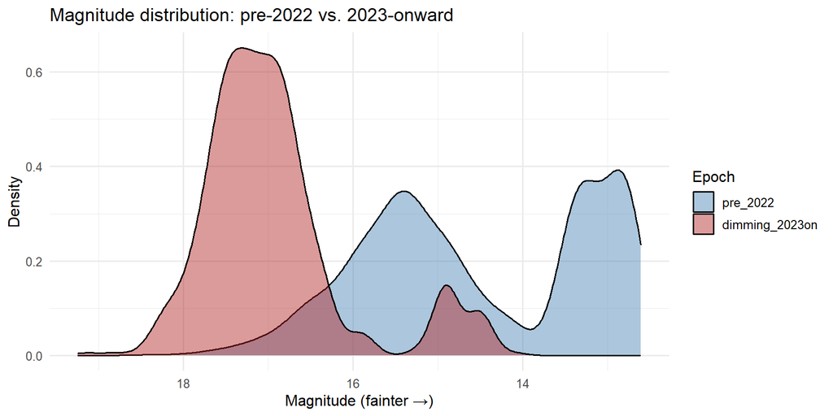

```r
ggplot(model_dat, aes(x = mag, fill = epoch)) +
  geom_density(alpha = 0.45) +
  scale_x_reverse() +
  scale_fill_manual(values = c(pre_2022 = "steelblue",
                               dimming_2023on = "firebrick")) +
  labs(title = "Magnitude distribution: pre-2022 vs. 2023-onward",
       x = "Magnitude (fainter →)", y = "Density", fill = "Epoch") +
  theme_minimal(base_size = 12)
```

# 4 Model 1 — Mean brightness (LMM)

We first model the **mean** magnitude. Magnitude is a continuous measurement, so this is a linear mixed model (Gaussian response), not a count GLM.

- **Fixed effect:** `epoch` — the pre-vs-post contrast we care about.
- **Random effect:** `(1 | band)` — each passband gets its own intercept, absorbing the systematic zero-point differences between filters.

$$\text{mag}_{ij} = \beta_0 + \beta_1\,\text{epoch}_i + b_j^{\text{band}} + \varepsilon_{ij}$$

```r
m_mean <- lmer(mag ~ epoch + (1 | band), data = model_dat, REML = TRUE)
summary(m_mean)
```

```
Linear mixed model fit by REML ['lmerMod']
Formula: mag ~ epoch + (1 | band)
   Data: model_dat

REML criterion at convergence: 14681.4

Scaled residuals:
    Min      1Q  Median      3Q     Max
-3.7096 -0.4497  0.1188  0.5756  4.8277

Random effects:
 Groups   Name        Variance Std.Dev.
 band     (Intercept) 1.1621   1.0780
 Residual             0.3922   0.6262
Number of obs: 7694, groups:  band, 6

Fixed effects:
                    Estimate Std. Error t value
(Intercept)         14.99644    0.44030   34.06
epochdimming_2023on  1.40910    0.03116   45.23

Correlation of Fixed Effects:
            (Intr)
epchdm_2023 -0.008
```

```r
# The epoch coefficient = change in mean magnitude, holding band constant.
tidy(m_mean, effects = "fixed", conf.int = TRUE) |>
  kable(digits = 4,
        caption = "Fixed effects. 'epochdimming_2023on' > 0 means fainter since 2023.")
```

Fixed effects. ‘epochdimming_2023on’ > 0 means fainter since 2023.

| effect | term | estimate | std.error | statistic | conf.low | conf.high |
| --- | --- | --- | --- | --- | --- | --- |
| fixed | (Intercept) | 14.9964 | 0.4403 | 34.0595 | 14.1335 | 15.8594 |
| fixed | epochdimming_2023on | 1.4091 | 0.0312 | 45.2272 | 1.3480 | 1.4702 |

# 5 Model 2 — Variability (location–scale GLMM)

The central question is about **variability**, not just the average. A standard mixed model assumes one common residual variance. Here we let the residual **dispersion depend on epoch** via `glmmTMB`’s `dispformula`, so the model estimates a separate spread for each era and tests whether they differ.

```r
m_scale <- glmmTMB(
  mag ~ epoch + (1 | band),
  dispformula = ~ epoch,          # <- variance is allowed to change by epoch
  data   = model_dat,
  family = gaussian()
)
summary(m_scale)
```

```
 Family: gaussian  ( identity )
Formula:          mag ~ epoch + (1 | band)
Dispersion:           ~epoch
Data: model_dat

      AIC       BIC    logLik -2*log(L)  df.resid
  14684.0   14718.8   -7337.0   14674.0      7689

Random effects:

Conditional model:
 Groups   Name        Variance Std.Dev.
 band     (Intercept) 0.9695   0.9846
 Residual                 NA       NA
Number of obs: 7694, groups:  band, 6

Conditional model:
                    Estimate Std. Error z value Pr(>|z|)
(Intercept)         14.99618    0.40219   37.29   <2e-16 ***
epochdimming_2023on  1.40862    0.02978   47.30   <2e-16 ***
---
Signif. codes:  0 '***' 0.001 '**' 0.01 '*' 0.05 '.' 0.1 ' ' 1

Dispersion model:
                     Estimate Std. Error z value Pr(>|z|)
(Intercept)         -0.464897   0.008348  -55.69   <2e-16 ***
epochdimming_2023on -0.055637   0.035598   -1.56    0.118
---
Signif. codes:  0 '***' 0.001 '**' 0.01 '*' 0.05 '.' 0.1 ' ' 1
```

```r
# Back-transform the dispersion model to a residual SD per epoch.
disp <- fixef(m_scale)$disp
sd_pre     <- sqrt(exp(disp[["(Intercept)"]]))
sd_dimming <- sqrt(exp(disp[["(Intercept)"]] + disp[["epochdimming_2023on"]]))

tibble(
  epoch          = c("pre_2022", "dimming_2023on"),
  residual_sd    = c(sd_pre, sd_dimming)
) |>
  kable(digits = 3,
        caption = "Model-estimated residual SD by epoch (the variability answer)")
```

Model-estimated residual SD by epoch (the variability answer)

| epoch | residual_sd |
| --- | --- |
| pre_2022 | 0.793 |
| dimming_2023on | 0.771 |

```r
cat(sprintf(
  "Variability change: residual SD goes from %.3f (pre-2022) to %.3f (2023 on) — a %.0f%% %s.\n",
  sd_pre, sd_dimming,
  100 * abs(sd_dimming - sd_pre) / sd_pre,
  ifelse(sd_dimming > sd_pre, "increase", "decrease")
))
```

```
Variability change: residual SD goes from 0.793 (pre-2022) to 0.771 (2023 on) — a 3% decrease.
```

## 5.1 Cross-check: simple variance test

An independent, model-free check on the same claim.

```r
var.test(mag ~ epoch, data = model_dat) |>
  broom::tidy() |>
  kable(digits = 4, caption = "F test for equal variances between epochs")
```

F test for equal variances between epochs

| estimate | num.df | den.df | statistic | p.value | conf.low | conf.high | method | alternative |
| --- | --- | --- | --- | --- | --- | --- | --- | --- |
| 2.3606 | 7226 | 466 | 2.3606 | 0 | 2.0593 | 2.6848 | F test to compare two variances | two.sided |

# 6 Diagnostics

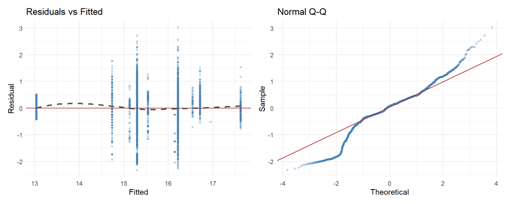

```r
diag_df <- tibble(
  fitted   = fitted(m_mean),
  residual = resid(m_mean)
)

p1 <- ggplot(diag_df, aes(fitted, residual)) +
  geom_point(alpha = 0.3, size = 1, colour = "steelblue") +
  geom_hline(yintercept = 0, colour = "firebrick") +
  geom_smooth(method = "loess", se = FALSE,
              colour = "grey30", linetype = "dashed") +
  labs(title = "Residuals vs Fitted", x = "Fitted", y = "Residual") +
  theme_minimal(base_size = 11)

p2 <- ggplot(diag_df, aes(sample = residual)) +
  stat_qq(alpha = 0.3, size = 1, colour = "steelblue") +
  stat_qq_line(colour = "firebrick") +
  labs(title = "Normal Q-Q", x = "Theoretical", y = "Sample") +
  theme_minimal(base_size = 11)

p1 + p2
```

# 7 +/-3 SD summary by epoch

```r
model_dat |>
  group_by(epoch) |>
  group_modify(~ sd3(.x$mag)) |>
  pivot_wider(names_from = epoch, values_from = value) |>
  kable(digits = 3, caption = "Magnitude +/-3 SD summary by epoch")
```

Magnitude +/-3 SD summary by epoch

| label | pre_2022 | dimming_2023on |
| --- | --- | --- |
| -3sd | 10.537 | 14.344 |
| -2sd | 11.867 | 15.210 |
| -1sd | 13.197 | 16.076 |
| Mean | 14.527 | 16.942 |
| +1sd | 15.857 | 17.808 |
| +2sd | 17.187 | 18.674 |
| +3sd | 18.517 | 19.540 |

# 8 Sensitivity check — Johnson V band only

```r
v_dat <- model_dat |> filter(band == "V") |> droplevels()

v_dat |>
  group_by(epoch) |>
  summarise(n = n(), mean_mag = mean(mag), sd_mag = sd(mag), .groups = "drop") |>
  kable(digits = 3, caption = "V band only: brightness and variability by epoch")
```

V band only: brightness and variability by epoch

| epoch | n | mean_mag | sd_mag |
| --- | --- | --- | --- |
| pre_2022 | 2782 | 15.280 | 0.808 |
| dimming_2023on | 206 | 17.024 | 0.376 |

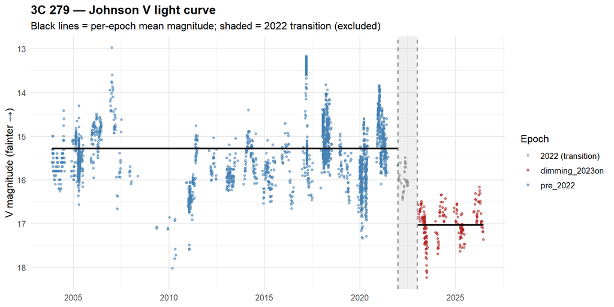

```r
# Full V-band history (all dates, so the 2022 transition is visible too).
v_all <- dat |>
  filter(band == "V") |>
  mutate(epoch = case_when(
    date <  PRE_END      ~ "pre_2022",
    date >= DIMMING_FROM ~ "dimming_2023on",
    TRUE                 ~ "2022 (transition)"
  ))

# Per-epoch mean magnitude, drawn as horizontal levels to show the dimming.
v_levels <- v_all |>
  filter(epoch != "2022 (transition)") |>
  group_by(epoch) |>
  summarise(
    xmin = min(date), xmax = max(date), mean_mag = mean(mag), .groups = "drop"
  )

ggplot(v_all, aes(date, mag)) +
  annotate("rect", xmin = PRE_END, xmax = DIMMING_FROM,
           ymin = -Inf, ymax = Inf, alpha = 0.08, fill = "grey20") +
  geom_point(aes(colour = epoch), alpha = 0.5, size = 1.1) +
  geom_segment(
    data = v_levels,
    aes(x = xmin, xend = xmax, y = mean_mag, yend = mean_mag),
    colour = "black", linewidth = 0.9, linetype = "solid"
  ) +
  geom_vline(xintercept = c(PRE_END, DIMMING_FROM),
             linetype = "dashed", colour = "grey40") +
  scale_y_reverse() +                       # brighter (smaller mag) at the top
  scale_colour_manual(values = c(
    "pre_2022"          = "steelblue",
    "2022 (transition)" = "grey55",
    "dimming_2023on"    = "firebrick"
  )) +
  labs(
    title    = "3C 279 — Johnson V light curve",
    subtitle = "Black lines = per-epoch mean magnitude; shaded = 2022 transition (excluded)",
    x = NULL, y = "V magnitude (fainter →)", colour = "Epoch"
  ) +
  theme_minimal(base_size = 12) +
  theme(plot.title = element_text(face = "bold"))
```

The single-band view makes the shift unambiguous: the 2023-onward cloud (red) sits both **lower** (fainter) and **tighter** (less scattered) than the pre-2022 cloud (blue), with the per-epoch mean levels showing the ~1.7 mag drop directly.

With a single band there is no random effect to include, so we fit a location–scale model with `epoch` in **both** the mean and the dispersion:

```r
m_v <- glmmTMB(
  mag ~ epoch,
  dispformula = ~ epoch,
  data   = v_dat,
  family = gaussian()
)
summary(m_v)
```

```
 Family: gaussian  ( identity )
Formula:          mag ~ epoch
Dispersion:           ~epoch
Data: v_dat

      AIC       BIC    logLik -2*log(L)  df.resid
   6899.3    6923.3   -3445.6    6891.3      2984


Conditional model:
                    Estimate Std. Error z value Pr(>|z|)
(Intercept)         15.27997    0.01533   997.0   <2e-16 ***
epochdimming_2023on  1.74380    0.03027    57.6   <2e-16 ***
---
Signif. codes:  0 '***' 0.001 '**' 0.01 '*' 0.05 '.' 0.1 ' ' 1

Dispersion model:
                    Estimate Std. Error z value Pr(>|z|)
(Intercept)         -0.21278    0.01341  -15.87   <2e-16 ***
epochdimming_2023on -0.76877    0.05106  -15.06   <2e-16 ***
---
Signif. codes:  0 '***' 0.001 '**' 0.01 '*' 0.05 '.' 0.1 ' ' 1
```

```r
# Mean shift and per-epoch residual SD, back-transformed.
dv <- fixef(m_v)$disp
tibble(
  quantity = c("mean shift (mag, + = fainter)",
               "residual SD pre_2022",
               "residual SD dimming_2023on"),
  value = c(
    fixef(m_v)$cond[["epochdimming_2023on"]],
    sqrt(exp(dv[["(Intercept)"]])),
    sqrt(exp(dv[["(Intercept)"]] + dv[["epochdimming_2023on"]]))
  )
) |>
  kable(digits = 3, caption = "V-only: mean and variability change")
```

V-only: mean and variability change

| quantity | value |
| --- | --- |
| mean shift (mag, + = fainter) | 1.744 |
| residual SD pre_2022 | 0.899 |
| residual SD dimming_2023on | 0.612 |

```r
var.test(mag ~ epoch, data = v_dat) |>
  broom::tidy() |>
  kable(digits = 4,
        caption = "V-only F test for equal variances between epochs")
```

V-only F test for equal variances between epochs

| estimate | num.df | den.df | statistic | p.value | conf.low | conf.high | method | alternative |
| --- | --- | --- | --- | --- | --- | --- | --- | --- |
| 4.6322 | 2781 | 205 | 4.6322 | 0 | 3.7552 | 5.6141 | F test to compare two variances | two.sided |

# 9 Summary